[figure not shown]

# **PREDICCIÓN DEMANDA ENERGÉTICA EN CALIFORNIA EN PERIODICIDAD HORARIA**

**Autor:**

Alejandro José Gómez Rivas

#### **Objetivo**

Realizar un análisis de la demanda de energía en California y calcular la predicción de los primeros 7 días de dic-2021 en periodicidad horaria y predicción diaria de los 15 primeros días de dic-2021. La predicción en periodicidad horaria se realizará en este script, mientras que la de periodicidad diaria se realizará en un script independiente.

### LIBRERÍA RECURRIDA

```python
import pandas as pd
import numpy as np
import matplotlib.pyplot as plt
import seaborn as sns
from datetime import datetime
import warnings
from sktime.forecasting.ets import AutoETS
from sktime.forecasting.arima import AutoARIMA
from sktime.utils.plotting import plot_correlations
from sktime.transformations.series.boxcox import LogTransformer
from sktime.forecasting.model_selection import temporal_train_test_split
from sktime.performance_metrics.forecasting import mean_absolute_percentage_error
from sktime.performance_metrics.forecasting import MeanSquaredError
from sktime.transformations.series.difference import Differencer
from sktime.forecasting.base import ForecastingHorizon
from sktime.utils.plotting import plot_series
from statsmodels.tsa.seasonal import STL
import statsmodels.api as sm
from statsmodels.graphics import tsaplots
from statsmodels.tsa.seasonal import seasonal_decompose
warnings.filterwarnings('ignore')
```

### LECTURA DE LOS DATOS

```python
df_hora = pd.read_excel('DemandaEnergia.xlsx', sheet_name='Hourly Data', usecols=['UTC time', 'demanda'], index_col='UTC time')
df_hora.index.rename('fecha', inplace=True) # renombramos la columna
```

```python
df_hora
```

| fecha | demanda |
| --- | --- |
| 2015-07-01 08:00:00 | 38210 |
| 2015-07-01 09:00:00 | 35171 |
| 2015-07-01 10:00:00 | 33243 |
| 2015-07-01 11:00:00 | 31955 |
| 2015-07-01 12:00:00 | 31199 |
| ... | ... |
| 2021-11-30 19:00:00 | 29068 |
| 2021-11-30 20:00:00 | 28769 |
| 2021-11-30 21:00:00 | 29180 |
| 2021-11-30 22:00:00 | 29719 |
| 2021-11-30 23:00:00 | 30512 |

56272 rows × 1 columns

### REPRESENTACIÓN GRÁFICA DE LOS DATOS

A continuación, se realiza una sencilla gráfica de línea para observar cómo se aprecia la demanda:

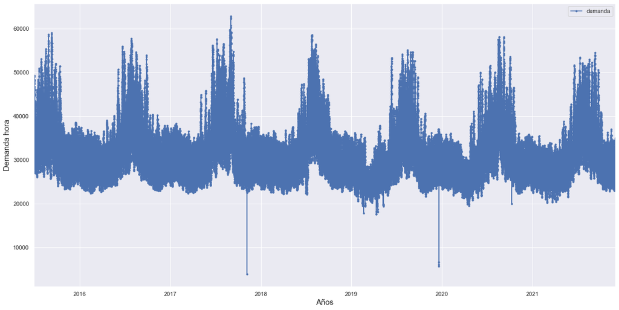

```python
sns.set(rc={'figure.figsize':(20, 10)})
fig = df_hora.plot(marker='.', linestyle='-')
fig.set_ylabel('Demanda hora', fontsize = 15)
fig.set_xlabel('Años', fontsize = 15);
```

Como podemos apreciar en el plot, hay un componente estacional bastante claro en la época de verano pero no se observa tendencia ninguna.

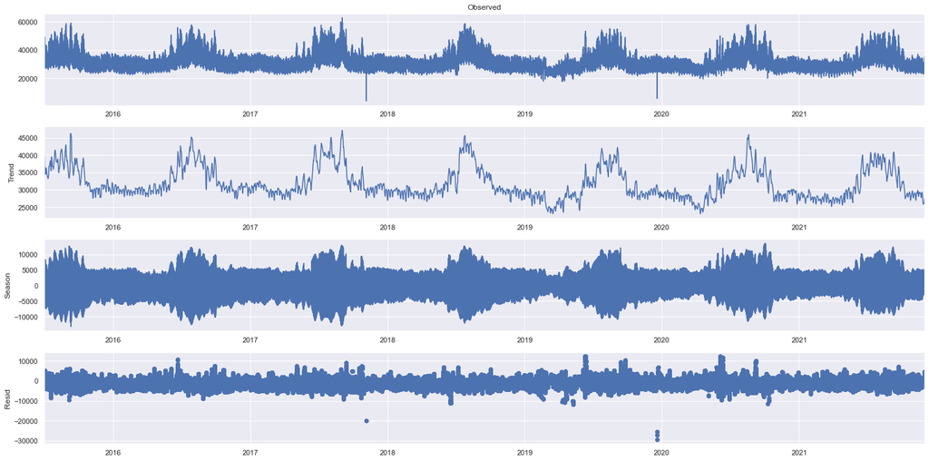

```python
df_hora = df_hora.asfreq('H')

res = STL(df_hora, robust=True).fit()
res.plot()
plt.show()
```

No se aprecia muy bien las tendencias y la estacionalidad. Sacaremos una muestra de 30 días para analizarlo mejor.

```python
df_hora = df_hora.loc['2021-11-01 00:00:00':]
```

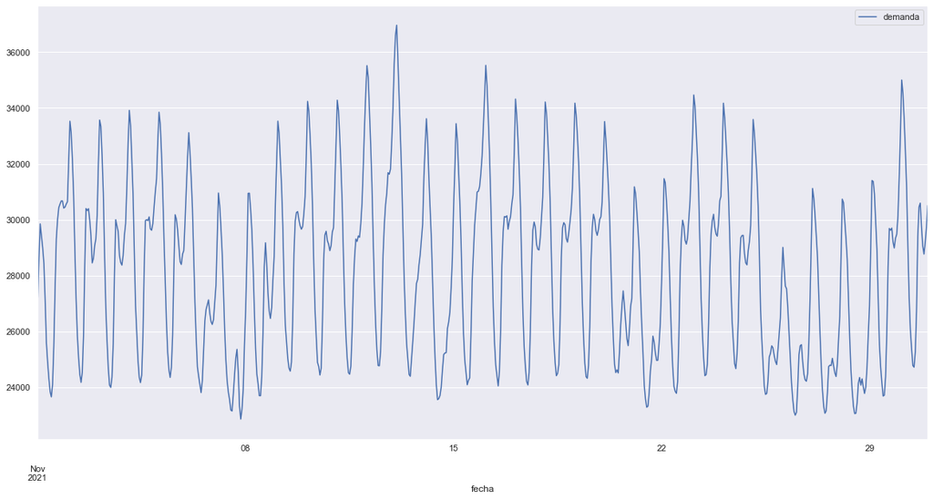

```python
df_hora.plot()
```

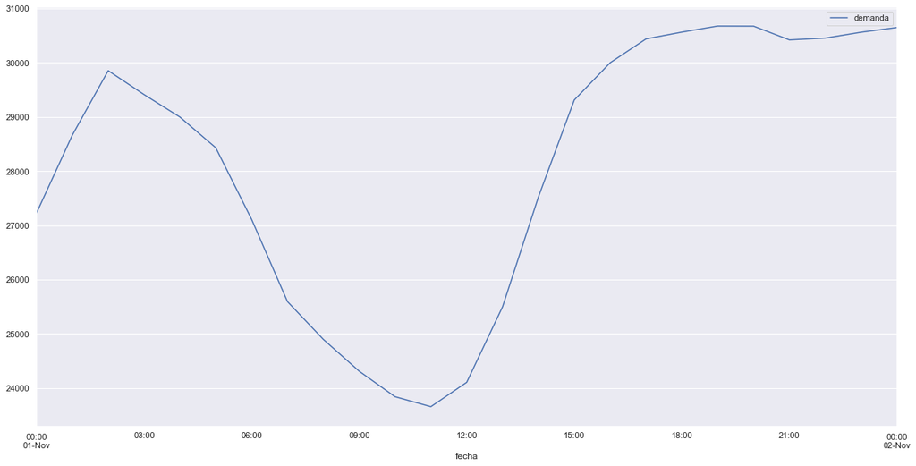

```python
df_undia = df_hora.loc['2021-11-01 00:00:00':'2021-11-02 00:00:00']
df_undia.plot()
```

La estacionalidad existe por la demanda energética en las horas en las que no hay luz solar.

```python
len(df_hora)
```

```
720
```

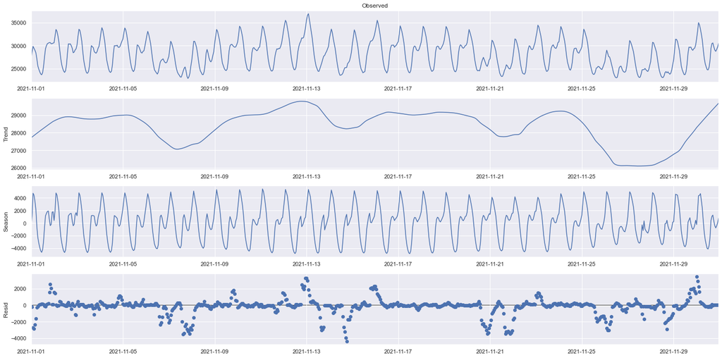

```python
df_hora = df_hora.asfreq('H')

res = STL(df_hora, robust=True).fit()
res.plot()
plt.show()
```

Se ve la clara estacionalidad vista anteriormente en un solo día y que no hay una tendencia clara, pues no sigue ningún patrón al alza o a la baja.

A continuación hacemos el train y test para poner en marcha distintos modelos de predicción.

```
576 144
```

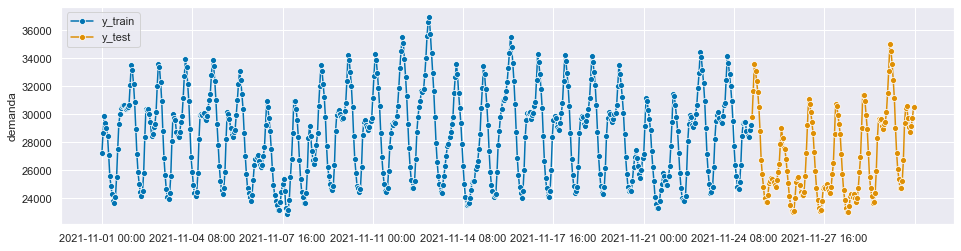

```python
y_train, y_test = temporal_train_test_split(y = df_hora['demanda'].astype('float64').to_period('H'), test_size=144)

plot_series(y_train, y_test, labels=["y_train", "y_test"])
print(y_train.shape[0], y_test.shape[0])
```

### MODELO ETS

```python
fh = np.arange(1, 145)
auto_ets = AutoETS(auto=True, sp=24, n_jobs=-1)
```

```python
auto_ets.fit(y_train);
```

```python
print(auto_ets.summary())
```

```
                                 ETS Results
==============================================================================
Dep. Variable:                demanda   No. Observations:                  576
Model:                      ETS(MAdM)   Log Likelihood               -4146.819
Date:                Fri, 21 Jan 2022   AIC                           8355.637
Time:                        12:23:02   BIC                           8490.677
Sample:                    11-01-2021   HQIC                          8408.301
                         - 11-24-2021   Scale                            0.000
Covariance Type:               approx
=======================================================================================
                          coef    std err          z      P>|z|      [0.025      0.975]
---------------------------------------------------------------------------------------
smoothing_level         0.9999      0.103      9.693      0.000       0.798       1.202
smoothing_trend         0.7391      0.205      3.606      0.000       0.337       1.141
smoothing_seasonal   9.686e-05        nan        nan        nan         nan         nan
damping_trend           0.8000      0.071     11.218      0.000       0.660       0.940
initial_level        2.805e+04        nan        nan        nan         nan         nan
initial_trend         109.2260    565.944      0.193      0.847   -1000.003    1218.455
initial_seasonal.0      0.9676        nan        nan        nan         nan         nan
initial_seasonal.1      0.9455        nan        nan        nan         nan         nan
initial_seasonal.2      0.9288        nan        nan        nan         nan         nan
initial_seasonal.3      0.9237        nan        nan        nan         nan         nan
initial_seasonal.4      0.9300        nan        nan        nan         nan         nan
initial_seasonal.5      0.9386        nan        nan        nan         nan         nan
initial_seasonal.6      0.9431        nan        nan        nan         nan         nan
initial_seasonal.7      0.9332        nan        nan        nan         nan         nan
initial_seasonal.8      0.9091        nan        nan        nan         nan         nan
initial_seasonal.9      0.8527        nan        nan        nan         nan         nan
initial_seasonal.10     0.8069        nan        nan        nan         nan         nan
initial_seasonal.11     0.7914        nan        nan        nan         nan         nan
initial_seasonal.12     0.7928        nan        nan        nan         nan         nan
initial_seasonal.13     0.8061        nan        nan        nan         nan         nan
initial_seasonal.14     0.8303        nan        nan        nan         nan         nan
initial_seasonal.15     0.8653        nan        nan        nan         nan         nan
initial_seasonal.16     0.9148        nan        nan        nan         nan         nan
initial_seasonal.17     0.9730        nan        nan        nan         nan         nan
initial_seasonal.18     1.0197        nan        nan        nan         nan         nan
initial_seasonal.19     1.0539        nan        nan        nan         nan         nan
initial_seasonal.20     1.0837        nan        nan        nan         nan         nan
initial_seasonal.21     1.0988        nan        nan        nan         nan         nan
initial_seasonal.22     1.0493        nan        nan        nan         nan         nan
initial_seasonal.23     1.0000        nan        nan        nan         nan         nan
===================================================================================
Ljung-Box (Q):                      222.67   Jarque-Bera (JB):                28.75
Prob(Q):                              0.00   Prob(JB):                         0.00
Heteroskedasticity (H):               0.53   Skew:                            -0.13
Prob(H) (two-sided):                  0.00   Kurtosis:                         4.06
===================================================================================

Warnings:
[1] Covariance matrix calculated using numerical (complex-step) differentiation.
```

```python
ets_y_pred_0 = auto_ets.predict(fh)
print(ets_y_pred_0)
```

```
2021-11-25 00:00    29980.913220
2021-11-25 01:00    31274.830616
2021-11-25 02:00    32596.395980
2021-11-25 03:00    32029.759038
2021-11-25 04:00    31052.566051
                        ...
2021-11-30 19:00    27069.051695
2021-11-30 20:00    26886.669364
2021-11-30 21:00    27035.827131
2021-11-30 22:00    27520.012996
2021-11-30 23:00    28163.864347
Freq: H, Length: 144, dtype: float64
```

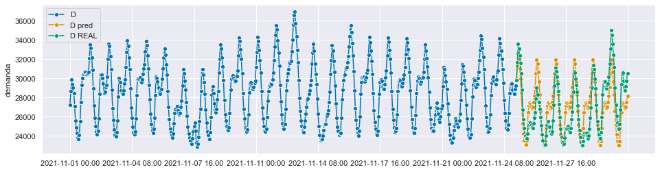

```python
plot = plot_series(y_train, ets_y_pred_0, y_test, labels=["D", "D pred", "D REAL"])
```

```
(<Figure size 1152x288 with 1 Axes>, <AxesSubplot:ylabel='demanda'>)
```

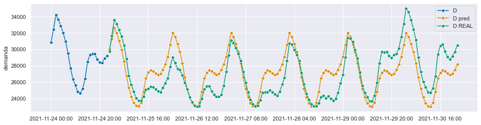

```python
plot_series(y_train['2021-11-24':], ets_y_pred_0, y_test, labels=["D", "D pred", "D REAL"])
```

#### Errores ETS:

```python
mean_absolute_percentage_error(y_test, ets_y_pred_0)
```

```
0.05918933981245887
```

```python
mse = MeanSquaredError()
mse(y_test, ets_y_pred_0)
```

```
3544510.213629566
```

```python
rmse = MeanSquaredError(square_root=True)
rmse(y_test, ets_y_pred_0)
```

```
1882.686966447042
```

Da un MAPE del 6% aproximadamente, lo cual significa que no es un modelo que prediga mal, al revés, predice con bastante precisión.

#### Predicción de los siguientes 7 días:

```python
fh = np.arange(1, 169)
y = df_hora['demanda'].astype('float64').to_period('H')

auto_ets = AutoETS(auto=True, sp=24, n_jobs=-1)
auto_ets.fit(y)
print(auto_ets.summary())
```

```
                                 ETS Results
==============================================================================
Dep. Variable:                demanda   No. Observations:                  720
Model:                      ETS(MAdM)   Log Likelihood               -5167.045
Date:                Fri, 21 Jan 2022   AIC                          10396.090
Time:                        12:23:05   BIC                          10538.047
Sample:                    11-01-2021   HQIC                         10450.893
                         - 11-30-2021   Scale                            0.000
Covariance Type:               approx
=======================================================================================
                          coef    std err          z      P>|z|      [0.025      0.975]
---------------------------------------------------------------------------------------
smoothing_level         0.9999      0.081     12.352      0.000       0.841       1.159
smoothing_trend         0.7536      0.158      4.784      0.000       0.445       1.062
smoothing_seasonal   7.703e-05        nan        nan        nan         nan         nan
damping_trend           0.8000      0.055     14.446      0.000       0.691       0.909
initial_level        2.805e+04        nan        nan        nan         nan         nan
initial_trend         109.2260    563.941      0.194      0.846    -996.078    1214.530
initial_seasonal.0      0.9668        nan        nan        nan         nan         nan
initial_seasonal.1      0.9431        nan        nan        nan         nan         nan
initial_seasonal.2      0.9269        nan        nan        nan         nan         nan
initial_seasonal.3      0.9222        nan        nan        nan         nan         nan
initial_seasonal.4      0.9291        nan        nan        nan         nan         nan
initial_seasonal.5      0.9390        nan        nan        nan         nan         nan
initial_seasonal.6      0.9436        nan        nan        nan         nan         nan
initial_seasonal.7      0.9357        nan        nan        nan         nan         nan
initial_seasonal.8      0.9130        nan        nan        nan         nan         nan
initial_seasonal.9      0.8580        nan        nan        nan         nan         nan
initial_seasonal.10     0.8149        nan        nan        nan         nan         nan
initial_seasonal.11     0.8008        nan        nan        nan         nan         nan
initial_seasonal.12     0.8031        nan        nan        nan         nan         nan
initial_seasonal.13     0.8179        nan        nan        nan         nan         nan
initial_seasonal.14     0.8425        nan        nan        nan         nan         nan
initial_seasonal.15     0.8780        nan        nan        nan         nan         nan
initial_seasonal.16     0.9284        nan        nan        nan         nan         nan
initial_seasonal.17     0.9858        nan        nan        nan         nan         nan
initial_seasonal.18     1.0299        nan        nan        nan         nan         nan
initial_seasonal.19     1.0624        nan        nan        nan         nan         nan
initial_seasonal.20     1.0912        nan        nan        nan         nan         nan
initial_seasonal.21     1.1057        nan        nan        nan         nan         nan
initial_seasonal.22     1.0527        nan        nan        nan         nan         nan
initial_seasonal.23     1.0000        nan        nan        nan         nan         nan
===================================================================================
Ljung-Box (Q):                      236.88   Jarque-Bera (JB):                29.72
Prob(Q):                              0.00   Prob(JB):                         0.00
Heteroskedasticity (H):               0.66   Skew:                            -0.07
Prob(H) (two-sided):                  0.00   Kurtosis:                         3.99
===================================================================================

Warnings:
[1] Covariance matrix calculated using numerical (complex-step) differentiation.
```

```
(<Figure size 1152x288 with 1 Axes>, <AxesSubplot:ylabel='demanda'>)
```

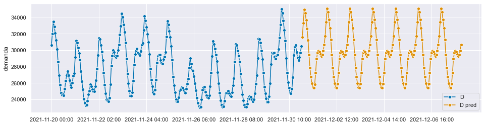

```python
y_pred_ets = auto_ets.predict(fh)
plot_series(y['2021-11-20':], y_pred, labels=["D", "D pred"])
```

### MODELO 2: ARIMA

```python
fh = np.arange(1, 145)
auto_arima = AutoARIMA(sp=24,suppress_warnings=True, n_jobs=-1)
auto_arima.fit(y_train)
```

```
AutoARIMA(n_jobs=-1, sp=24, suppress_warnings=True)
```

```python
print(auto_arima.summary())
```

```
                                     SARIMAX Results
==========================================================================================
Dep. Variable:                                  y   No. Observations:                  576
Model:             SARIMAX(1, 0, 2)x(1, 0, 2, 24)   Log Likelihood               -4226.759
Date:                            Fri, 21 Jan 2022   AIC                           8469.518
Time:                                    12:14:40   BIC                           8504.367
Sample:                                         0   HQIC                          8483.108
                                            - 576
Covariance Type:                              opg
==============================================================================
                 coef    std err          z      P>|z|      [0.025      0.975]
------------------------------------------------------------------------------
intercept   1373.8376    288.977      4.754      0.000     807.453    1940.223
ar.L1          0.8197      0.020     40.228      0.000       0.780       0.860
ma.L1          0.7068      0.038     18.566      0.000       0.632       0.781
ma.L2          0.3367      0.044      7.697      0.000       0.251       0.422
ar.S.L24       0.7378      0.042     17.403      0.000       0.655       0.821
ma.S.L24      -0.0728      0.062     -1.184      0.236      -0.193       0.048
ma.S.L48       0.1029      0.048      2.131      0.033       0.008       0.197
sigma2      1.331e+05   7863.238     16.929      0.000    1.18e+05    1.49e+05
===================================================================================
Ljung-Box (L1) (Q):                   4.66   Jarque-Bera (JB):                65.05
Prob(Q):                              0.03   Prob(JB):                         0.00
Heteroskedasticity (H):               0.82   Skew:                             0.58
Prob(H) (two-sided):                  0.18   Kurtosis:                         4.17
===================================================================================

Warnings:
[1] Covariance matrix calculated using the outer product of gradients (complex-step).
```

```python
arima_y_pred_0 = auto_arima.predict(fh)
arima_y_pred_0
```

```
2021-11-25 00:00    29369.433870
2021-11-25 01:00    30569.060371
2021-11-25 02:00    32049.238655
2021-11-25 03:00    31845.104115
2021-11-25 04:00    31379.457359
                        ...
2021-11-30 19:00    29009.102347
2021-11-30 20:00    28953.100440
2021-11-30 21:00    28936.335834
2021-11-30 22:00    29019.940021
2021-11-30 23:00    29077.713481
Freq: H, Length: 144, dtype: float64
```

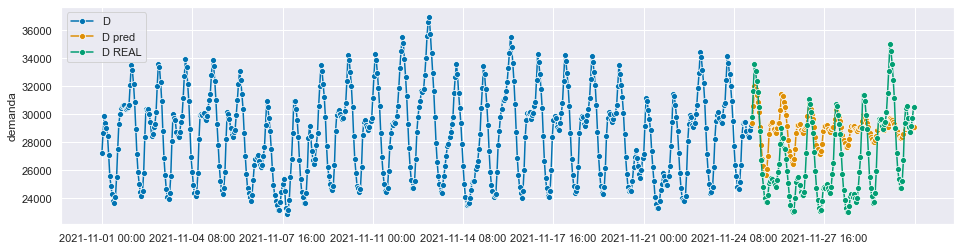

```python
plot = plot_series(y_train, arima_y_pred_0, y_test, labels=["D", "D pred", "D REAL"])
```

```
(<Figure size 1152x288 with 1 Axes>, <AxesSubplot:ylabel='demanda'>)
```

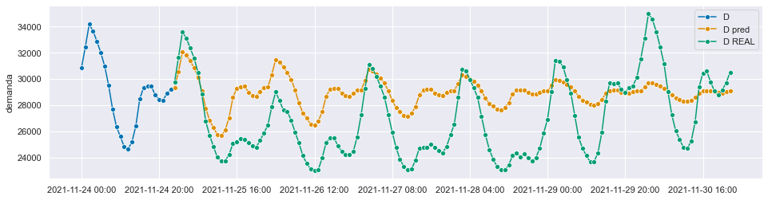

```python
plot_series(y_train['2021-11-24':], arima_y_pred_0, y_test, labels=["D", "D pred", "D REAL"])
```

#### Errores ARIMA:

```python
mean_absolute_percentage_error(y_test, arima_y_pred_0)
```

```
0.0959349891973518
```

```python
mse = MeanSquaredError()
mse(y_test, arima_y_pred_0)
```

```
9246973.006105376
```

```python
rmse = MeanSquaredError(square_root=True)
rmse(y_test, arima_y_pred_0)
```

```
3040.883589699773
```

Como aquí la predicción no es muy buena y su MAPE es superior al del modelo ETS, no tendría sentido realizar una predicción de los siguiente 7 días. Ahora vamos a guardar los datos predecidos con ETS y lo guardamos en un CSV.

#### Recogida de datos predecidos con el modelo ETS y conversión en archivo CSV

```python
y_pred_ets
```

```
2021-12-01 00:00    31598.262579
2021-12-01 01:00    33294.315601
2021-12-01 02:00    34998.701116
2021-12-01 03:00    34561.772800
2021-12-01 04:00    33666.817974
                        ...
2021-12-07 19:00    29499.557900
2021-12-07 20:00    29282.362256
2021-12-07 21:00    29429.350361
2021-12-07 22:00    29944.997273
2021-12-07 23:00    30697.168481
Freq: H, Length: 168, dtype: float64
```

```python
y_pred_ets.to_csv('y_pred_ets_hourly.csv', index=True)
```